# Etude d’un sondage sur le temps de travail des étudiants

Mehdi Elmesbahi, Jules Bernière, Daphné Grangé

2023-12-14

**Présentation et objectifs de l’étude**

Nous allons présenter une étude afin de tenter de répondre à la problématique suivante :

**Quels facteurs influent le plus sur le temps travaillé selon le genre de l’individu ?**

Nous nous sommes appuyés sur le sondage effectué par les étudiants de L3 économie de l’[université de Tours](https://www.univ-tours.fr/).

L’étude est basée sur l’analyse de 208 individus ayant répondu au sondage dont 168 sont des étudiants inscrits en filière Économie, soit 80.8% des répondantes et répondants. L’échantillon est constitué de 134 hommes et de 74 femmes. L’âge des répondants se situe entre 16 et 31 ans. L’âge moyen est de 19 ans.

# **Age et genre des étudiants**

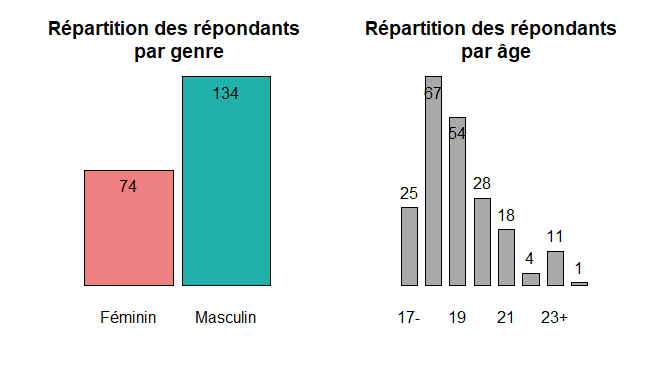

Répartition des répondants par filière

|  | autre | économie | gestion | Total |
| --- | --- | --- | --- | --- |
| **Licence** |  |  |  |  |
| L1 | 2 | 93 | 36 | 131 |
| L2 | 1 | 31 | 1 | 33 |
| L3 | 0 | 44 | 0 | 44 |
| Total | 3 | 168 | 37 | 208 |

# **Etude du nombre de soirées hebdomadaires**

Tableau descriptif du nombre de soirées hebdomadaires en fonction du genre

| Genre | Nombre de soirées 0 | Nombre de soirées 0.25 | Nombre de soirées 0.5 | Nombre de soirées 1 | Nombre de soirées 2 | Nombre de soirées 3 | Nombre de soirées 4 | Total |
| --- | --- | --- | --- | --- | --- | --- | --- | --- |
| Féminin | 40 | 0 | 0 | 26 | 6 | 1 | 1 | 74 |
| Masculin | 54 | 1 | 9 | 42 | 24 | 4 | 0 | 134 |
| Total | 94 | 1 | 9 | 68 | 30 | 5 | 1 | 208 |

Les valeurs surlignées en gris correspondent aux réponses les plus fréquentes.

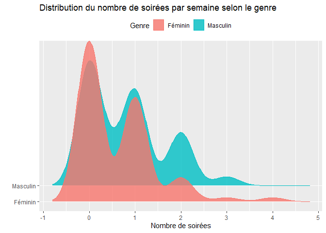

Pour soutenir les interprétations graphiques, nous pouvons faire un test du χ².

Le test d’indépendance nous donne une p-value égale à **0.04**<0.05. Ceci nous permet de conclure que le genre est corrélé avec le nombre de soirées hebdomadaires.

# **Lien entre la consommation d’alcool et les réseaux sociaux**

Nous allons tout d’abord regarder si les réseaux sociaux influence les habitudes de consommation des étudiants, en l’occurence la consommation d’alccol.

```
## [1] 0
```

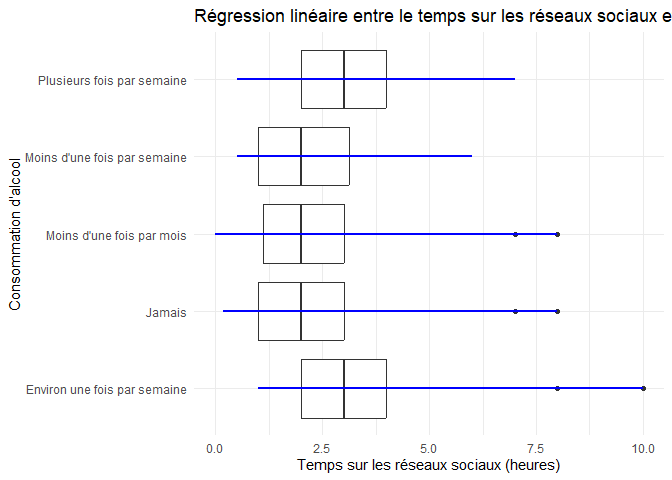

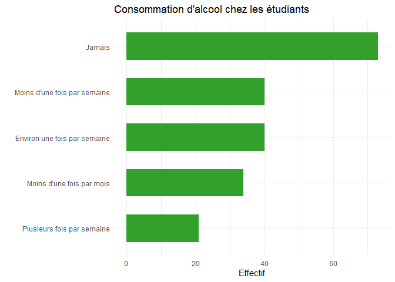

La réponse majoritaire des étudiants est qu’ils ne consomment jamais d’alcool.

# **Lien entre le genre et les réseaux sociaux**

Tableau descriptif du temps passé par jour sur les réseaux sociaux en heure en fonction du genre

| Genre | Temps passé par jour sur les réseaux sociaux en heure 0 | Temps passé par jour sur les réseaux sociaux en heure 0.17 | Temps passé par jour sur les réseaux sociaux en heure 0.3 | Temps passé par jour sur les réseaux sociaux en heure 0.5 | Temps passé par jour sur les réseaux sociaux en heure 1 | Temps passé par jour sur les réseaux sociaux en heure 1.5 | Temps passé par jour sur les réseaux sociaux en heure 2 | Temps passé par jour sur les réseaux sociaux en heure 2.5 | Temps passé par jour sur les réseaux sociaux en heure 3 | Temps passé par jour sur les réseaux sociaux en heure 3.3 | Temps passé par jour sur les réseaux sociaux en heure 3.5 | Temps passé par jour sur les réseaux sociaux en heure 4 | Temps passé par jour sur les réseaux sociaux en heure 5 | Temps passé par jour sur les réseaux sociaux en heure 6 | Temps passé par jour sur les réseaux sociaux en heure 7 | Temps passé par jour sur les réseaux sociaux en heure 8 | Temps passé par jour sur les réseaux sociaux en heure 10 | Total |
| --- | --- | --- | --- | --- | --- | --- | --- | --- | --- | --- | --- | --- | --- | --- | --- | --- | --- | --- |
| Féminin | 1 | 0 | 1 | 1 | 9 | 3 | 16 | 2 | 14 | 0 | 1 | 12 | 3 | 4 | 4 | 3 | 0 | 74 |
| Masculin | 1 | 1 | 0 | 5 | 33 | 10 | 34 | 3 | 23 | 1 | 0 | 11 | 5 | 5 | 0 | 1 | 1 | 134 |
| Total | 2 | 1 | 1 | 6 | 42 | 13 | 50 | 5 | 37 | 1 | 1 | 23 | 8 | 9 | 4 | 4 | 1 | 208 |

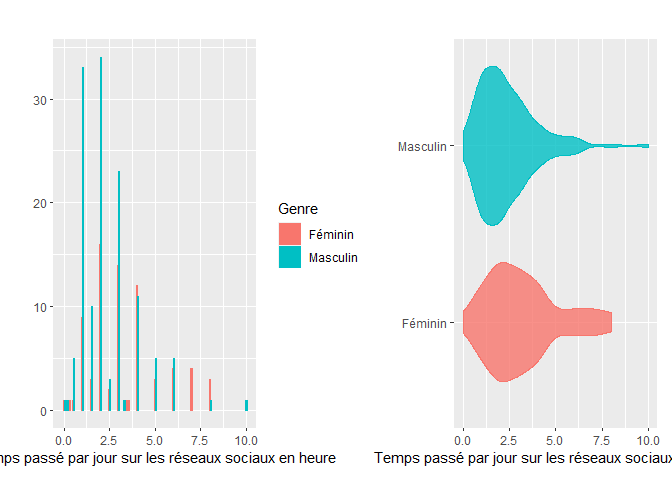

Graphiquement on ne trouve pas de corrélation entre le genre et le temps passé sur les réseaux. Le test d’indépendance nous donne une p-value égale à **0.15**>0.05.

Ce qui nous permet de confirmer l’absence de corrélation entre le genre et le temps passé sur les réseaux sociaux.

# **Lien entre le temps de travail personnel et le nombre de soirées**

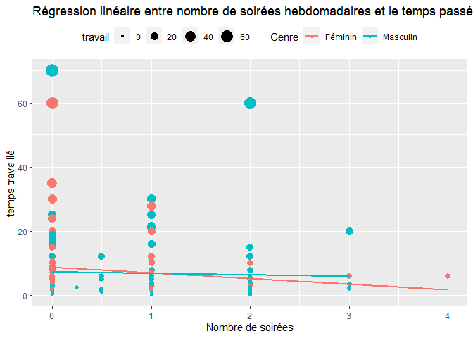

Nous observons une pente légerement négative pour les hommes et les femmes. Cepandant il semblerait que le nombre de soirées chez les femmes influe légerement plus a la baisse sur le temps passé a travailler que chez les hommes.

Les estimateurs pour les hommes sont la constante et le coefficient linéaire, qui sont respectivement 7.28 et -0.46. Tandis que pour les femmes ces estimateurs sont 8.72 et -1.76.

| \|r\|% proche de | Puissance du lien |
| --- | --- |
| 0 | Nulle |
| 50 | Faible |
| 75 | Moyenne |
| 87 | Forte |
| 100 | Très Forte |

Le test de corrélation donne répectivement pour les hommes, les femmes et au total :

```
## cor
##  -4
```

```
## cor
## -16
```

```
## cor
##  -8
```

Ainsi, en effectuant les tests séparemment pour les hommes et les femmes nous pouvons conclure qu’il n’existe pas de corrélation significative entre les deux variables étudiées.

# **Conclusion**